# Analyzing Airline Flight Performance: Cancellations & Delays

### Cancellation Per week Day

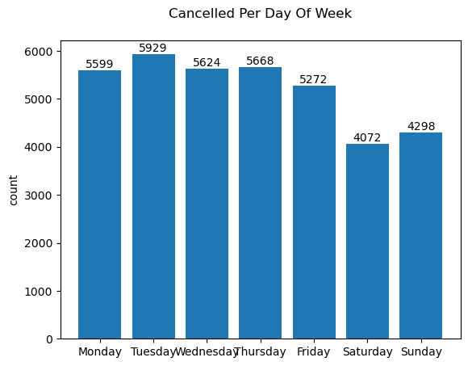

```python
bar_chart(canceled_airline_df.sort_values(['DayOfWeek']),
        'DayOfWeek_Desc',
        'Cancelled Per Day Of Week',)
```

##### Cancellation Per Quarter

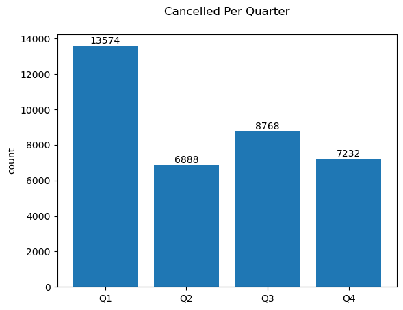

```python
bar_chart(canceled_airline_df.sort_values(['Quarter']),
        'Quarter_Desc',
        'Cancelled Per Quarter',)
```

### Cancellation based On Cancellation Code

Examining the causes of cancellations reveals that 44% of the cancellations are attributed to unspecified reasons. Causes A and B account for approximately 40% of the cancellations.

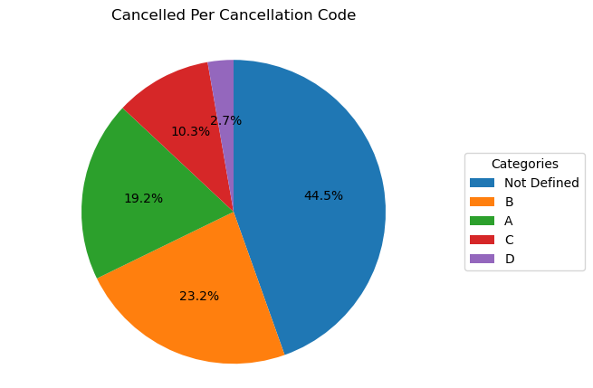

```python
pie_chart(canceled_airline_df.sort_values(['CancellationCode']),
        'CancellationCode',
        'Cancelled Per Cancellation Code')
```

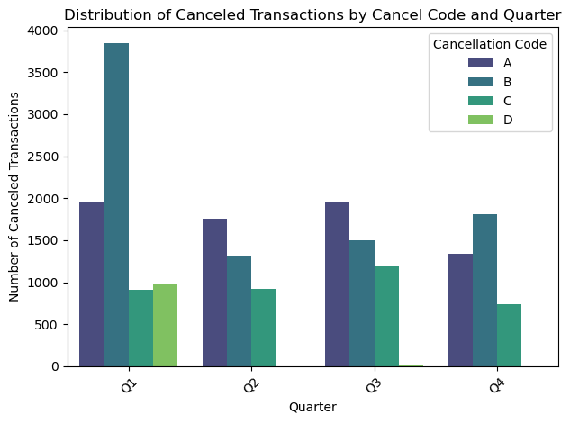

```python
# Plotting
sns.barplot(data=canceled_airline_df_agg, x='Quarter_Desc', y='Count', hue='CancellationCode', palette='viridis')

# Title and labels
plt.title('Distribution of Canceled Transactions by Cancel Code and Quarter')
plt.xlabel('Quarter')
plt.ylabel('Number of Canceled Transactions')


plt.legend(title='Cancellation Code')
plt.xticks(rotation=45)
plt.tight_layout()
```

## Distribution of Delay

#### Distribution Of Arrival Delay Groups and DepartureDelayGroups

The histogram below illustrates the distribution of arrival and departure delays. It shows that most data points are concentrated at the lower end of the range, with only a small number extending into the higher end. This distribution is highly skewed to the right, indicating that while most flights experience minimal or no delays, there are a few significant delays that create a long tail on the right side of the chart

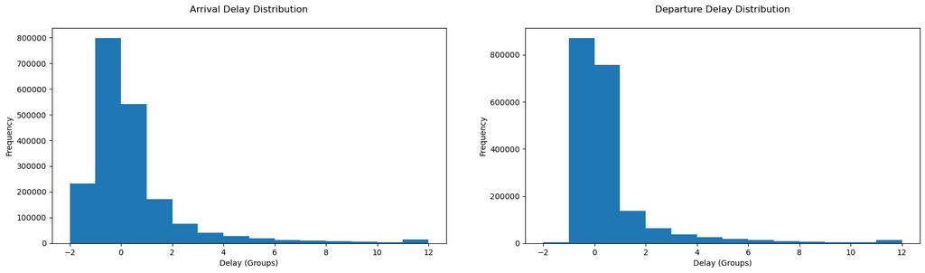

```python
two_hist_chart(cleaned_airline_df,
               ['ArrivalDelayGroups', 'DepartureDelayGroups'],
               ['Arrival Delay Distribution', 'Departure Delay Distribution'],
                ['Delay (Groups)', 'Delay (Groups)'])
```

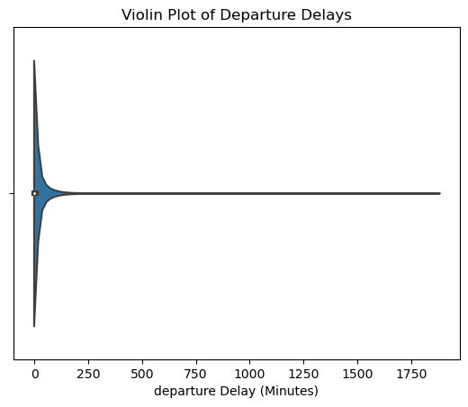

```python
sns.violinplot(x=df['DepDelayMinutes'].dropna())
plt.xlabel('departure Delay (Minutes)')
plt.title('Violin Plot of Departure Delays')
plt.show()
```

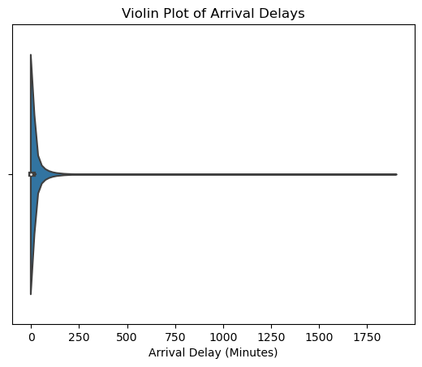

```python
sns.violinplot(x=df['ArrDelayMinutes'].dropna())
plt.xlabel('Arrival Delay (Minutes)')
plt.title('Violin Plot of Arrival Delays')
plt.show()
```

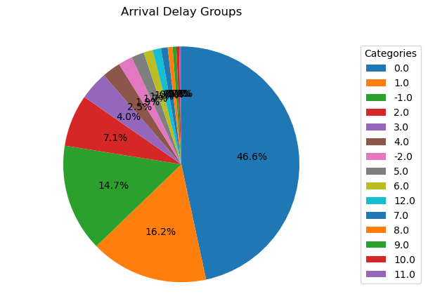

```python
pie_chart(delay_airline_df, 'ArrivalDelayGroups','Arrival Delay Groups')
```